# Activity Monitoring

Cesar Garcia

January 22, 2017

## Introduction (excerpt from assignment)

It is now possible to collect a large amount of data about personal movement using activity monitoring devices such as a [Fitbit](http://fitbit.com), [Nike Fuelband](http://www.nike.com/us/en_us/c/nikeplus-fuelband), or [Jawbone Up](https://jawbone.com/up). These type of devices are part of the “quantified self” movement – a group of enthusiasts who take measurements about themselves regularly to improve their health, to find patterns in their behavior, or because they are tech geeks. But these data remain under-utilized both because the raw data are hard to obtain and there is a lack of statistical methods and software for processing and interpreting the data.

This assignment makes use of data from a personal activity monitoring device. This device collects data at 5 minute intervals through out the day. The data consists of two months of data from an anonymous individual collected during the months of October and November, 2012 and include the number of steps taken in 5 minute intervals each day.

## Read the data

```r
activity <- read.csv(unz("activity.zip","activity.csv"))
```

## Mean total number of steps taken per day

### Histogram of steps taken each day

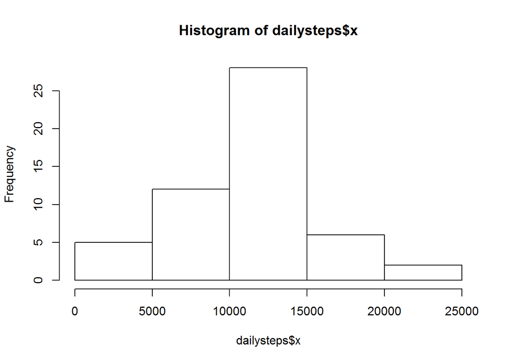

```r
dailysteps <- aggregate(activity$steps,by=list(Day=activity$date),FUN=sum)
hist(dailysteps$x)
```

### Mean and Median total number of steps taken each day

```r
meansteps <- mean(dailysteps$x,na.rm = TRUE)
meadiansteps <- median(dailysteps$x,na.rm = TRUE)
```

The mean number of steps taken each day is 10,766.19 and the number of median steps taken each day is 10,765

### Average daily activity pattern

-What is the average daily pattern?-

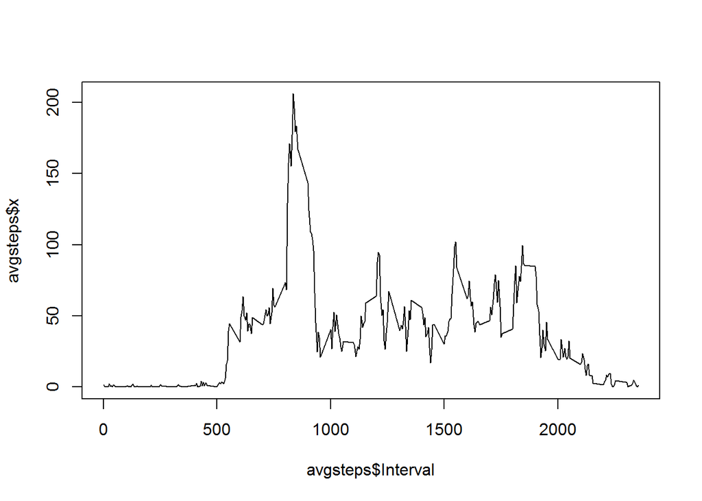

```r
avgsteps <- aggregate(activity$steps,by=list(Interval=activity$interval),FUN=mean,na.rm=TRUE)
plot(avgsteps$Interval,avgsteps$x,type="l")
```

```r
maxInterval <- avgsteps$Interval[which.max(avgsteps$x)]
```

The highest average step count happened during interval 835

- Imputting missing values-

```r
missingsteps <- sum(is.na(activity$steps))
```

There are 2,304 in the dataset. In order to have a better picture of the data, the missing values in steps will be replaced by the mean value of the steps in that interval.

```r
avgintervals <- aggregate(activity$steps,by=list(interval=activity$interval),FUN=mean,na.rm=TRUE)
newactivity <- activity
for(i in 1:nrow(newactivity)) {
  if(is.na(newactivity$steps[i]) == TRUE) {
    newactivity$steps[i] = avgintervals[avgintervals$interval==newactivity$interval[i],2]

  }
}
```

- Histogram of daily steps with NAs replaced -

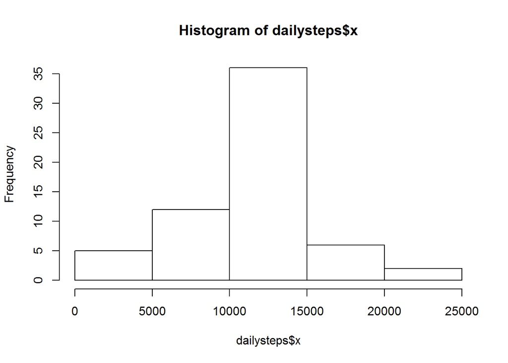

```r
dailysteps <- aggregate(newactivity$steps,by=list(Day=newactivity$date),FUN=sum)
hist(dailysteps$x)
```

- Mean and Median total number of steps taken each day -

```r
meanstepsnew <- mean(dailysteps$x,na.rm = TRUE)
meadianstepsnew <- median(dailysteps$x,na.rm = TRUE)
```

The mean number of steps taken each day of the new data set is 10,766.19 and the number of median steps taken each day is 10,766.19.

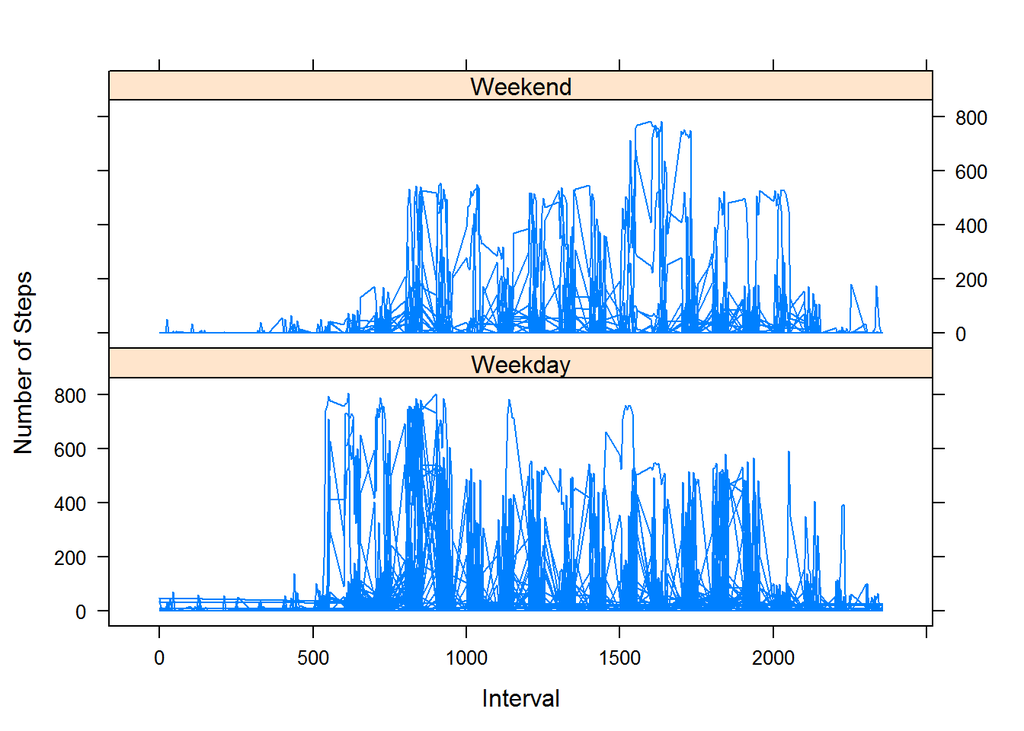

```r
newactivity$period <- ifelse(weekdays(as.Date(newactivity$date),abbreviate=TRUE) %in% c("Sat","Sun"),"Weekend","Weekday")

library(lattice)
 xyplot(steps~interval|period,type='l',layout=c(1,2),xlab='Interval',ylab='Number of Steps',data=newactivity)
```